# 鋳造製品の欠陥検出 (SIGNATE 練習問題用コンペティション)

#### 【課題】

製造業でのAI導入は今後ますます発展が見込まれます。現状では人で品質管理をしている場合でも、データを集め、機械学習や深層学習を用いることにより省力化やコスト削減を実現することが可能です。  
今回は製造業へのAI導入という課題に対して、鋳造製品の画像データを用いて、PyTorchというライブラリを使いながら、欠陥検出を予測する画像分類モデルの作成に挑戦します。

#### 【本コンペについて】

このコンペティションは『鋳造製品の画像データを使って、欠陥を検出するモデルを作成する』という内容の練習課題です。  
コンペティション内では検出済みの学習用画像データ 「train_data.zip」、未検出のテスト用画像データ 「test_data.zip」が配布されています。  
train_data.zipの画像データを用いて画像分類モデルを作成し、モデルを用いてtest_data.zipの画像データから鋳造製品の欠陥の有無を判定する『画像分類問題』になります。（zip解凍済み）

※配布データの再配布は禁止

#### 【データ概要】課題種別：画像 データ種別：画像データ 学習データサンプル数：250

##### １．画像の読み込み、欠陥の確認

##### ２．画像分類モデルの作成準備

##### ３．欠陥検出モデルの作成（転移学習有）

##### ４．未知の画像データに対する推論

### １．画像の読み込み&確認

まずは今回の分析に使用するライブラリをすべてimportします。それぞれ以下の機能が提供されています。

numpy：数値計算、pandas：データ加工、os：OSに依存した機能（主にファイルやディレクトリ操作）を利用、PIL（Pillow）：画像処理、  
matplotlib：画像をプロット＆グラフの描画、torch：Pytorch画像認識モデル作成、torchvision：Pytorchデータセット作成

```python
# numpy, pandas, os, Pillow, matplotlibライブラリ
import numpy as np
import pandas as pd
import os
from PIL import Image, ImageDraw
import matplotlib.pyplot as plt

# Pytorchライブラリ
import torch
# ニューラルネットワーク、損失関数
import torch.nn as nn
# 最適化関数
import torch.optim as optim
# Pytorchデータセット
from torchvision import datasets, models, transforms
```

今回の機械学習(深層学習)モデルの構築には『Pytorch』という機械学習ライブラリを使用します。  
PyTorchは初心者向けの機械学習ライブラリ『Tensorflow＆Keras』よりも、拡張性や自由度が高く処理速度が速いのが特徴です。  
ただし、実装がシンプルなKerasよりも可読性が低いです。

次に、配布されたtrain_data.zip内の鋳造製品の画像データを見てみましょう。  
解凍後のtrain_dataフォルダ内の画像は250枚存在し、正常品(OK)の画像が100枚、欠陥品(NG)の画像が150枚揃っています。  
それらOKとNGの画像を学習用フォルダ「train」と評価用フォルダ「val」に、4：1の割合で分割し、さらにそれぞれ「ok」フォルダと「ng」フォルダにまとめます。  
つまり、学習用の「train」フォルダ内に「ok(80枚)」「ng(120枚)」フォルダ、評価用の「val」フォルダ内に「ok(20枚)」「ng(30枚)」フォルダ、という形に手動で整理します。

```python
# ok,ngフォルダ内画像データのリストを取得
train_ok_image_name_list = os.listdir('signate_data/casting/train/ok/')
train_ng_image_name_list = os.listdir('signate_data/casting/train/ng/')
val_ok_image_name_list = os.listdir('signate_data/casting/val/ok/')
val_ng_image_name_list = os.listdir('signate_data/casting/val/ng/')

# リストの大きさ表示
print('学習用OK画像：', len(train_ok_image_name_list), '枚')
print('学習用NG画像：', len(train_ng_image_name_list), '枚')
print('評価用OK画像：', len(val_ok_image_name_list), '枚')
print('評価用NG画像：', len(val_ng_image_name_list), '枚')
```

```
学習用OK画像： 80 枚
学習用NG画像： 120 枚
評価用OK画像： 20 枚
評価用NG画像： 30 枚
```

下は1枚の正常品の画像を図として表示した例です。

```
画像データのフォーマット : JPEG
画像データのサイズ : (300, 300)
画像データのモード : RGB
```

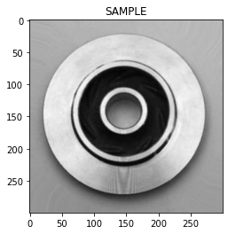

```python
# 鋳造製品の画像データの読み込み
img = Image.open('signate_data/casting/train/ok/cast_ok_0_147.jpeg')

print('画像データのフォーマット :', img.format)
print('画像データのサイズ :', img.size)
print('画像データのモード :', img.mode)

# 画像の表示
plt.imshow(img)
plt.title('SAMPLE')
plt.show()
```

正常である鋳造製品の画像は以下の様に表示されます。（学習用80枚 + 評価用20枚 = 100枚）

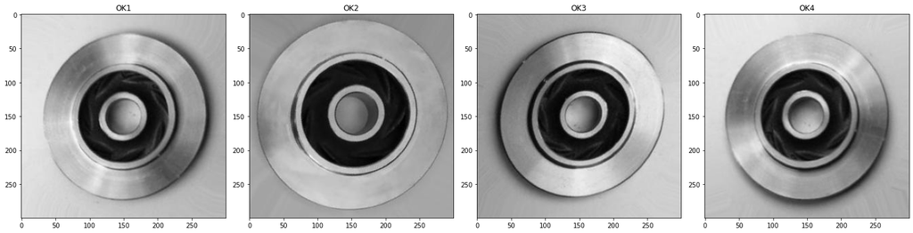

```python
# 鋳造製品(正常品)の画像データの読み込み
im1 = Image.open('signate_data/casting/train/ok/cast_ok_0_149.jpeg')
im2 = Image.open('signate_data/casting/train/ok/cast_ok_0_152.jpeg')
im3 = Image.open('signate_data/casting/train/ok/cast_ok_0_153.jpeg')
im4 = Image.open('signate_data/casting/train/ok/cast_ok_0_154.jpeg')

plt.figure(figsize=(20, 20))
# 画像表示
# 1行4列の1番目
plt.subplot(1,4,1)
plt.imshow(im1)
plt.title('OK1')

# 1行4列の2番目
plt.subplot(1,4,2)
plt.imshow(im2)
plt.title('OK2')

# 1行4列の3番目
plt.subplot(1,4,3)
plt.imshow(im3)
plt.title('OK3')

# 1行4列の4番目
plt.subplot(1,4,4)
plt.imshow(im4)
plt.title('OK4')

# 画像の表示
plt.tight_layout()
plt.show()
```

一方、欠陥のある鋳造製品の画像は以下の様に表示されます。（学習用120枚 + 評価用30枚 = 150枚）  
赤い矩形（長方形）で囲った箇所に引っ掻きキズが付いているのが分かります。キズ以外にも、円盤周辺にバリが付いている画像も含まれています。

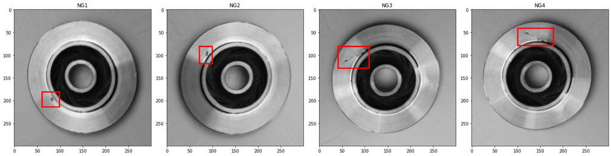

```python
# 鋳造製品(欠陥品)の画像データの読み込み
im5 = Image.open('signate_data/casting/train/ng/cast_def_0_0.jpeg')
im6 = Image.open('signate_data/casting/train/ng/cast_def_0_109.jpeg')
im7 = Image.open('signate_data/casting/train/ng/cast_def_0_105.jpeg')
im8 = Image.open('signate_data/casting/train/ng/cast_def_0_107.jpeg')

# 画像の大きさ
plt.figure(figsize=(20, 20))

# 図形描画
d5 = ImageDraw.Draw(im5)
d5.rectangle(xy=[(60, 180),(100, 215)], outline='red', width=3)

d6 = ImageDraw.Draw(im6)
d6.rectangle(xy=[(70, 80),(100, 120)], outline='red', width=3)

d7 = ImageDraw.Draw(im7)
d7.rectangle(xy=[(40, 80),(110, 130)], outline='red', width=3)

d8 = ImageDraw.Draw(im8)
d8.rectangle(xy=[(100, 40),(180, 80)], outline='red', width=3)

# 画像表示
# 1行4列の1番目
plt.subplot(1,4,1)
plt.imshow(im5)
plt.title('NG1')

# 1行4列の2番目
plt.subplot(1,4,2)
plt.imshow(im6)
plt.title('NG2')

# 1行4列の3番目
plt.subplot(1,4,3)
plt.imshow(im7)
plt.title('NG3')

# 1行4列の4番目
plt.subplot(1,4,4)
plt.imshow(im8)
plt.title('NG4')

# 画像の表示
plt.tight_layout()
plt.show()
```

これらの分割した正常品と欠陥品の画像を用いてモデルに学習＆評価をさせていきます。(この手法をホールドアウト法と言う)  
その後、作成したモデルによって未検出であるテストデータの画像を判定します。

### ２．データセットの作成

Pytorchは様々な画像認識モデルの機能を提供します。  
画像認識とは、画像から特徴を「抽出・分析・識別」して認識検出する手法の一つです。  
画像認識モデルでは通常『畳み込みニューラルネットワーク』という画像認識用のニューラルネットワーク（人間の神経細胞を模したモデル）が使用されます。

ただ今回の画像分類モデルを作成する前に、準備として『データセット』を作成する必要があります。  
データセットとは「機械学習モデルが読み込んで、学習を行う状態にまで加工したデータ」のことを言います。  
現時点では画像データがokとngのフォルダに含まれているだけで、各画像に対してのクラスラベル（各データに与えられる正解。今回は「欠陥の有無」）は付いていません。  
この状態ではモデルの学習はできないので、入力データとそれに対応するクラスラベルを1組返すように設定する必要があります。

Pytorchではtransforms、Dataset、DataLoaderの3つのモジュールを使って、データの正規化やサイズ統一などの前処理、ラベル付け、バッチサイズ化をまとめて行いデータセットを作成します。

#### 【transforms/Dataset/DataLoaderの役割】

#### transforms

##### ・データ前処理を定義するモジュール

#### Dataset

##### ・データと対応するラベルを1組返すモジュール

##### ・transformsを使って定義した前処理を画像データに対して行うモジュール

#### DataLoader

##### ・データセットからデータをバッチサイズに固めて返すモジュール

データセット作成の流れは transforms➞Dataset➞DataLoader となっており、画像分類モデルはDataLoaderによって渡されるデータを元に学習します。

### ① transforms

```python
# transforms定義
data_transforms = {
    'train': transforms.Compose([
        transforms.Resize(256),
        transforms.RandomHorizontalFlip(p=0.5), # p=0.5指定でランダム反転
        transforms.ToTensor(),
        transforms.Normalize([0.485, 0.456, 0.406], [0.229, 0.224, 0.225]), # 平均に[0.485, 0.456, 0.406]、標準偏差に[0.229, 0.224, 0.225]を指定
    ]),
    'val': transforms.Compose([
        transforms.Resize(256),
        transforms.ToTensor(),
        transforms.Normalize([0.485, 0.456, 0.406], [0.229, 0.224, 0.225]),
    ]),
}

# transforms定義を確認
print(data_transforms)
```

```
{'train': Compose(
    Resize(size=256, interpolation=bilinear)
    RandomHorizontalFlip(p=0.5)
    ToTensor()
    Normalize(mean=[0.485, 0.456, 0.406], std=[0.229, 0.224, 0.225])
), 'val': Compose(
    Resize(size=256, interpolation=bilinear)
    ToTensor()
    Normalize(mean=[0.485, 0.456, 0.406], std=[0.229, 0.224, 0.225])
)}
```

### ② Dataset

Datasetでは入力データとそれに対応するラベルを1組返す処理を行います。transforms同様に学習用と評価用と分けて書きます。  
以下のdatasets.ImageFolderでは、引数で指定したパスでの画像がクラスラベルごと（＝フォルダごと）に読み込まれ、transformsに定義したデータ処理を行います。

```python
# dataset作成
image_datasets = {
    'train': datasets.ImageFolder('signate_data/casting/train/', data_transforms['train']),
    'val': datasets.ImageFolder('signate_data/casting/val/', data_transforms['val'])
}

# datasetの定義を確認
print(image_datasets)
```

```
{'train': Dataset ImageFolder
    Number of datapoints: 200
    Root location: signate_data/casting/train/
    StandardTransform
Transform: Compose(
               Resize(size=256, interpolation=bilinear)
               RandomHorizontalFlip(p=0.5)
               ToTensor()
               Normalize(mean=[0.485, 0.456, 0.406], std=[0.229, 0.224, 0.225])
           ), 'val': Dataset ImageFolder
    Number of datapoints: 50
    Root location: signate_data/casting/val/
    StandardTransform
Transform: Compose(
               Resize(size=256, interpolation=bilinear)
               ToTensor()
               Normalize(mean=[0.485, 0.456, 0.406], std=[0.229, 0.224, 0.225])
           )}
```

データ元を確認するとng画像が「0」、ok画像が「1」にラベル付けされていることが確認できます。

```python
# ng画像のdatasetを確認
print(image_datasets['train'].samples[0])
```

```
('signate_data/casting/train/ng\\cast_def_0_0.jpeg', 0)
```

```python
# ok画像のdatasetを確認
print(image_datasets['train'].samples[150])
```

```
('signate_data/casting/train/ok\\cast_ok_0_250.jpeg', 1)
```

```python
# クラスラベルの割り振り(ng:0, ok:1)
print(image_datasets['train'].class_to_idx)
```

```
{'ng': 0, 'ok': 1}
```

### ③ DataLoader

Dataloaderは、Datasetから画像データを『バッチサイズ』ごとに取り出すことを目的に使われます。  
機械学習におけるバッチサイズとは、学習後のパラメータ更新を行う間隔のことを言います。間隔で分けた少数のサンプルをミニバッチと呼びます。  
例えば、200枚の学習用画像データがありバッチサイズを5と設定した場合、5枚のミニバッチごとに学習＆パラメータ更新されるので、更新は40回行われます。

ミニバッチごとにデータを取り出すことによって、計算機のスペックに合わせて学習を行うことができます。  
Dataloaderでは以下のtorch.utils.data.DataLoaderを用いて、バッチサイズ、データのshuffle等の設定をします。

```python
# dataloaders作成
image_dataloaders = {
    'train': torch.utils.data.DataLoader(image_datasets['train'], batch_size=5, shuffle=True),
    'val': torch.utils.data.DataLoader(image_datasets['val'], batch_size=5, shuffle=False),
}

for i, (inputs, labels) in enumerate(image_dataloaders['train']):
            print(inputs)
            print(labels)
            if i == 0:
                break

# 入力データ(テンソル化済み)とラベルを1バッチ表示
print(image_dataloaders, '\n')
# 各データのバッチ数を確認
print('学習用データのバッチ数：',len(image_dataloaders['train']))
print('評価用データのバッチ数：',len(image_dataloaders['val']))
```

[output not shown]

[output cut: 73 more lines]

```
          [0.9930, 0.9930, 0.9755,  ..., 0.3102, 0.2927, 0.2752],
          [0.9755, 0.9755, 0.9755,  ..., 0.3102, 0.2927, 0.2752]],

         [[1.5071, 1.5071, 1.5071,  ..., 0.9494, 0.9494, 0.9319],
          [1.4897, 1.5071, 1.5071,  ..., 0.9494, 0.9319, 0.9319],
          [1.4897, 1.4897, 1.5071,  ..., 0.9319, 0.9319, 0.9145],
          ...,
          [1.2108, 1.2108, 1.2108,  ..., 0.5311, 0.5136, 0.4962],
          [1.2108, 1.2108, 1.1934,  ..., 0.5311, 0.5136, 0.4962],
          [1.1934, 1.1934, 1.1934,  ..., 0.5311, 0.5136, 0.4962]]]])
tensor([1, 1, 1, 1, 0])
{'train': <torch.utils.data.dataloader.DataLoader object at 0x000002AF55038BB0>, 'val': <torch.utils.data.dataloader.DataLoader object at 0x000002AF550382E0>}

学習用データのバッチ数： 40
評価用データのバッチ数： 10
```

ここで、image_datasetsの個数からdataset_sizesを作成しておきます。dataset_sizesは「３．欠陥検出モデルの作成」のモデル学習の実装に使用します。

```python
dataset_sizes = {
    'train': len(image_datasets['train']),
    'val': len(image_datasets['val']),
}

print('学習用データセット内の個数：', dataset_sizes['train'])
print('評価用データセット内の個数：', dataset_sizes['val'])
```

```
学習用データセット内の個数： 200
評価用データセット内の個数： 50
```

### ３．欠陥検出モデルの作成（転移学習有）

今回は『ResNet18』という畳み込みニューラルネットワークを用いて『転移学習』ありでモデル作成を行います。(ResNet18の詳細は省く)  
転移学習とは、Imagenetという1400万枚以上の画像データセットを事前に学習させたモデルのパラメータを流用して、新たなモデルを作成する手法です。  
一からモデルを学習させる必要が無いので、学習させるためのデータ数が少なくても精度の高いモデルを作成することができます。

モデル作成のためにget_model関数を定義します。  
関数の内容は、ResNet18(転移学習有)で畳み込み層とプーリング層と呼ばれるニューラルネットワークの層を与えて画像の特徴を検出し、  
Linearで全結合層という層を与えて抽出された特徴量を用いて、演算を行い予測結果を出力する流れになります。  
学習の処理では処理装置としてCPUを指定します。また、モデルの出力サイズは2に設定します。

```python
# 定数の設定（device：処理装置, target_num：出力サイズ）
device = "cpu"
target_num = 2

# モデル作成関数の定義
def get_model(target_num):
    model_ft = models.resnet18(pretrained=True)
    model_ft.fc = nn.Linear(512, target_num)
    model_ft = model_ft.to(device)
    return model_ft

# 事前学習済みResNet18モデルのインスタンス作成
pretrained_model = get_model(target_num=2)

# 事前学習済みモデルを表示
print(pretrained_model)
```

```
ResNet(
  (conv1): Conv2d(3, 64, kernel_size=(7, 7), stride=(2, 2), padding=(3, 3), bias=False)
  (bn1): BatchNorm2d(64, eps=1e-05, momentum=0.1, affine=True, track_running_stats=True)
  (relu): ReLU(inplace=True)
  (maxpool): MaxPool2d(kernel_size=3, stride=2, padding=1, dilation=1, ceil_mode=False)
  (layer1): Sequential(
    (0): BasicBlock(
      (conv1): Conv2d(64, 64, kernel_size=(3, 3), stride=(1, 1), padding=(1, 1), bias=False)
      (bn1): BatchNorm2d(64, eps=1e-05, momentum=0.1, affine=True, track_running_stats=True)
      (relu): ReLU(inplace=True)
      (conv2): Conv2d(64, 64, kernel_size=(3, 3), stride=(1, 1), padding=(1, 1), bias=False)
      (bn2): BatchNorm2d(64, eps=1e-05, momentum=0.1, affine=True, track_running_stats=True)
    )
    (1): BasicBlock(
      (conv1): Conv2d(64, 64, kernel_size=(3, 3), stride=(1, 1), padding=(1, 1), bias=False)
      (bn1): BatchNorm2d(64, eps=1e-05, momentum=0.1, affine=True, track_running_stats=True)
      (relu): ReLU(inplace=True)
      (conv2): Conv2d(64, 64, kernel_size=(3, 3), stride=(1, 1), padding=(1, 1), bias=False)
      (bn2): BatchNorm2d(64, eps=1e-05, momentum=0.1, affine=True, track_running_stats=True)
    )
  )
  (layer2): Sequential(
    (0): BasicBlock(
      (conv1): Conv2d(64, 128, kernel_size=(3, 3), stride=(2, 2), padding=(1, 1), bias=False)
      (bn1): BatchNorm2d(128, eps=1e-05, momentum=0.1, affine=True, track_running_stats=True)
      (relu): ReLU(inplace=True)
      (conv2): Conv2d(128, 128, kernel_size=(3, 3), stride=(1, 1), padding=(1, 1), bias=False)
      (bn2): BatchNorm2d(128, eps=1e-05, momentum=0.1, affine=True, track_running_stats=True)
      (downsample): Sequential(
        (0): Conv2d(64, 128, kernel_size=(1, 1), stride=(2, 2), bias=False)
        (1): BatchNorm2d(128, eps=1e-05, momentum=0.1, affine=True, track_running_stats=True)
      )
    )
    (1): BasicBlock(
      (conv1): Conv2d(128, 128, kernel_size=(3, 3), stride=(1, 1), padding=(1, 1), bias=False)
      (bn1): BatchNorm2d(128, eps=1e-05, momentum=0.1, affine=True, track_running_stats=True)
      (relu): ReLU(inplace=True)
      (conv2): Conv2d(128, 128, kernel_size=(3, 3), stride=(1, 1), padding=(1, 1), bias=False)
      (bn2): BatchNorm2d(128, eps=1e-05, momentum=0.1, affine=True, track_running_stats=True)
    )
```

[output cut: 29 more lines]

```
        (0): Conv2d(256, 512, kernel_size=(1, 1), stride=(2, 2), bias=False)
        (1): BatchNorm2d(512, eps=1e-05, momentum=0.1, affine=True, track_running_stats=True)
      )
    )
    (1): BasicBlock(
      (conv1): Conv2d(512, 512, kernel_size=(3, 3), stride=(1, 1), padding=(1, 1), bias=False)
      (bn1): BatchNorm2d(512, eps=1e-05, momentum=0.1, affine=True, track_running_stats=True)
      (relu): ReLU(inplace=True)
      (conv2): Conv2d(512, 512, kernel_size=(3, 3), stride=(1, 1), padding=(1, 1), bias=False)
      (bn2): BatchNorm2d(512, eps=1e-05, momentum=0.1, affine=True, track_running_stats=True)
    )
  )
  (avgpool): AdaptiveAvgPool2d(output_size=(1, 1))
  (fc): Linear(in_features=512, out_features=2, bias=True)
)
```

次にモデルの予測精度を評価するために、予測値と実際の値のズレの大きさを表すloss（損失）関数を選定します。  
ネットワークを学習させる過程でloss（損失）関数の値が小さくなるほど、学習が上手くいき正確なモデルに近づきます。  
今回は正常品であるか欠陥品であるかを判定する「2値分類問題」となるため、よく使用される交差エントロピー誤差(CrossEntropyLoss)を用います。

```python
# loss（損失）関数の定義
criterion = nn.CrossEntropyLoss()
```

『最適化アルゴリズム』には確率的勾配降下法(SGD)を用います。今回の様な2値分類モデルの学習を行う際に利用されます。  
最適化アルゴリズムとは、loss関数の最小値と最小値となるパラメータを求めるためのアルゴリズムです。  
SGDはミニバッチごとに更新する手法なので、データ全体で学習するよりも計算効率が高くなりやすく、局所解に陥りにくい利点があります。

```python
# 最適化関数の定義
optimizer = optim.SGD(pretrained_model.parameters(), lr=0.001, momentum=0.9)
```

このモデルに対して画像を入力した際の出力は、正常品であるか欠陥品であるかの2値分類となっているため、出力は例えば[0.121, 0.912]という形になっています。  
もしある画像の入力に対して出力が[0.121, 0.912]であれば、値の大きいindexは1(=正常品のクラスラベル)となるので、モデルはその画像を正常品に分類していることになります。

モデル学習のための関数train_modelを定義します。

```python
# エポック数(=全データによる学習＆評価の「試行回数」)
epochs=5
# モデル保存の有無
is_saved=True
# グラフ可視化するためのloss,acc配列
train_loss_tensor = []
train_acc_tensor = []
val_loss_tensor= []
val_acc_tensor = []


# モデル訓練用関数
def train_model(model, criterion, optimizer, num_epochs, is_saved=False):
    best_acc = 0.0

    # エポック数だけ下記工程の繰り返し
    for epoch in range(num_epochs):

        print('エポック', epoch+1)

        for phase in ['train', 'val']:
            print('{}:フェイズ'.format(phase))

            # 訓練フェイズと検証フェイズの切り替え
            if phase == 'train':
                model.train()
            else:
                model.eval()

            running_loss = 0.0
            running_corrects = 0

            # dataloadersからバッチサイズ(=5)だけデータ取り出し、下記工程（1−5）を40回繰り返す
            for i, (inputs, labels) in enumerate(image_dataloaders[phase]):
                inputs, labels = inputs.to(device), labels.to(device)

                # 1. optimizerの勾配初期化
                optimizer.zero_grad()

                # 2.モデルに入力データ(画像データ5枚分のテンソル)をinputし、outputを取り出す
                outputs = model(inputs)
                _, preds = torch.max(outputs, 1)

                # 3. outputと正解ラベルから、lossを算出
                loss = criterion(outputs, labels)

                # 5の倍数回でlossを出力
                if (i+1) % 5 == 0:
                    print('   loaders:{}回目'.format(i+1)  ,'   loss:{}'.format(loss))

                # loss配列に誤差の数値を追加
                if phase == 'train':
                    train_loss_tensor.append(loss)
                else:
                    val_loss_tensor.append(loss)

                # 学習時のみ勾配算出とパラメータ更新を行う
                if phase == 'train':
                    # 4. 誤差逆伝播法により勾配の算出
                    loss.backward()
                    # 5. 勾配を用いてoptimizerのパラメータ更新
                    optimizer.step()

                # 個別のloss = lossの値 × バッチサイズ5の足し上げ
                running_loss += loss.item() * inputs.size(0)
                # 正解数 = 正解と出力のクラスラベルが合っていた数の足し上げ
                running_corrects += torch.sum(preds == labels.data)

            # 個別lossの値をデータサイズで割り、平均のlossを算出
            epoch_loss = running_loss / dataset_sizes[phase]
            # 正解数をデータサイズで割り、正解率Accuracyを算出
            epoch_acc = running_corrects.double() / dataset_sizes[phase]
            print('{} Loss: {:.4f} {} Acc: {:.4f}'.format(phase, epoch_loss, phase, epoch_acc))

            # acc配列に正解率の数値を追加
            if phase == 'train':
                train_acc_tensor.append(epoch_acc)
            else:
                val_acc_tensor.append(epoch_acc)

            # C. 今までのエポックでの精度よりも高い場合はモデルの保存
            if phase == 'val' and epoch_acc > best_acc:
                best_acc = epoch_acc
                if(is_saved):
                    torch.save(model.state_dict(), './original_model.pth')

    print('Best val Acc: {:4f}'.format(best_acc))
```

train_modelを実行しモデルの学習をします。  
計5回の各エポックの中で、trainフェイズでの学習が40回、valフェイズでの評価が10回ずつ行われ、その後指定の場所にモデルが保存されます。

```python
# 作成した事前学習済みモデル、loss（損失）関数、最適化アルゴリズム等を用いて学習
model_ft = train_model(pretrained_model, criterion, optimizer, epochs, is_saved)
```

```
エポック 1
train:フェイズ
   loaders:5回目    loss:0.9057778120040894
   loaders:10回目    loss:0.6292241811752319
   loaders:15回目    loss:0.4116785526275635
   loaders:20回目    loss:0.5196505784988403
   loaders:25回目    loss:0.7112045884132385
   loaders:30回目    loss:0.15170033276081085
   loaders:35回目    loss:1.0360201597213745
   loaders:40回目    loss:0.14988550543785095
train Loss: 0.6030 train Acc: 0.6850
val:フェイズ
   loaders:5回目    loss:0.4727378785610199
   loaders:10回目    loss:0.099130779504776
val Loss: 0.3662 val Acc: 0.8400
エポック 2
train:フェイズ
   loaders:5回目    loss:0.11114798486232758
   loaders:10回目    loss:0.27796903252601624
   loaders:15回目    loss:0.4647494852542877
   loaders:20回目    loss:0.5510560274124146
   loaders:25回目    loss:0.6186545491218567
   loaders:30回目    loss:0.22914083302021027
   loaders:35回目    loss:0.20412969589233398
   loaders:40回目    loss:0.33982783555984497
train Loss: 0.3528 train Acc: 0.8400
val:フェイズ
   loaders:5回目    loss:0.10448267310857773
   loaders:10回目    loss:0.043208103626966476
val Loss: 0.1713 val Acc: 0.9200
エポック 3
train:フェイズ
   loaders:5回目    loss:0.20708195865154266
   loaders:10回目    loss:0.47638851404190063
   loaders:15回目    loss:0.06226373836398125
   loaders:20回目    loss:0.16029855608940125
   loaders:25回目    loss:0.022498613223433495
   loaders:30回目    loss:0.04262427240610123
   loaders:35回目    loss:0.0030991309322416782
   loaders:40回目    loss:0.028766581788659096
```

[output cut: 21 more lines]

```
train:フェイズ
   loaders:5回目    loss:0.0020597404800355434
   loaders:10回目    loss:0.0013458018656820059
   loaders:15回目    loss:0.11262552440166473
   loaders:20回目    loss:0.02419343777000904
   loaders:25回目    loss:0.011767550371587276
   loaders:30回目    loss:0.004645416978746653
   loaders:35回目    loss:0.03292417898774147
   loaders:40回目    loss:0.0016954740276560187
train Loss: 0.0909 train Acc: 0.9850
val:フェイズ
   loaders:5回目    loss:0.0031226854771375656
   loaders:10回目    loss:0.01791195198893547
val Loss: 0.0305 val Acc: 1.0000
Best val Acc: 1.000000
```

モデルの学習でloss(誤差)とacc(正解率)がどの様に変化しているかを、グラフで可視化してみましょう。  
まず上の処理で作成したloss, accの配列をテンソル型からリスト型へ変換します。

```python
# 変換後の配列
train_loss_list = []
train_acc_list = []
val_loss_list = []
val_acc_list = []

# tensor型からlist型へ変換
for train_loss_item in train_loss_tensor:
    train_loss_list.append(train_loss_item.detach().numpy())

for train_acc_item in train_acc_tensor:
    train_acc_list.append(train_acc_item.detach().numpy())

for val_loss_item in val_loss_tensor:
    val_loss_list.append(val_loss_item.detach().numpy())

for val_acc_item in val_acc_tensor:
    val_acc_list.append(val_acc_item.detach().numpy())
```

```python
# list型に変換できたか確認
print(type(train_loss_list))
print(type(train_acc_list))
print(type(val_loss_list))
print(type(val_acc_list))
```

```
<class 'list'>
<class 'list'>
<class 'list'>
<class 'list'>
```

リスト型に変換できたので、matplotlibを用いてグラフ化できるようになりました。  
以下のグラフは、200回の学習プロセスと50回の評価プロセスの中で、損失関数による誤差の増減をプロットしたものです。  
学習時の青い曲線が激しく変動しながら減少しているのに対し、評価時の赤い曲線は青い曲線より低い位置で減少しています。

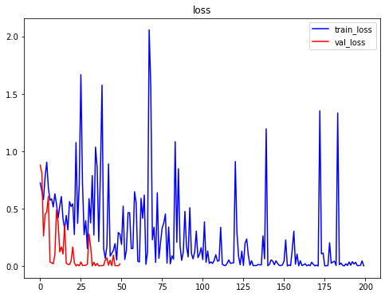

```python
# 学習曲線(loss：誤差)を表示
plt.figure(figsize=(8,6))
plt.plot(train_loss_list, label='train_loss', c='b')
plt.plot(val_loss_list, label='val_loss', c='r')
plt.title('loss')
plt.xticks(size=10)
plt.yticks(size=10)
plt.legend(fontsize=10)
plt.show()
```

また、もう一つのグラフは5エポックの中で、正解率の増減をプロットしたものです。  
学習時の青い曲線が増加していくのに対し、評価時の赤い曲線は青い曲線より高い位置で増加しています。

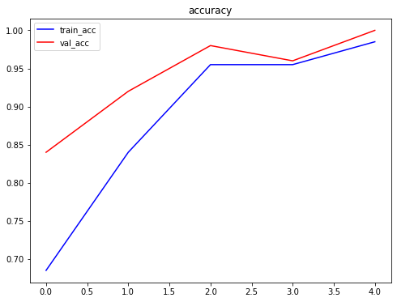

```python
# 学習曲線(acc：正解率)を表示
plt.figure(figsize=(8,6))
plt.plot(train_acc_list, label='train_acc', c='b')
plt.plot(val_acc_list, label='val_acc', c='r')
plt.title('accuracy')
plt.xticks(size=10)
plt.yticks(size=10)
plt.legend(fontsize=10)
plt.show()
```

評価プロセスにおいて学習プロセスよりも「低い誤差かつ高い正解率」という結果が出たので過学習はなく、分類モデルが高い精度で学習できていることが分かります。

### ４．未知の画像データに対する推論

保存した画像分類モデルを用いて、未知の画像データ100枚を分類します。  
まず、テストデータの画像を読み込みます。

```python
# テストデータの読み込み＆DataFrame作成
df_test = pd.DataFrame(data=os.listdir('signate_data/casting/test/test/'))

# カラム名を変更
df_test = df_test.rename(columns={0: 'filename'})
```

```python
# 読み込んだテストデータの確認
df_test
```

|  | filename |
| --- | --- |
| 0 | 1009937.jpeg |
| 1 | 109996.jpeg |
| 2 | 119892.jpeg |
| 3 | 129893.jpeg |
| 4 | 139981.jpeg |
| ... | ... |
| 95 | 969983.jpeg |
| 96 | 979891.jpeg |
| 97 | 989921.jpeg |
| 98 | 99851.jpeg |
| 99 | 999921.jpeg |

100 rows × 1 columns

「２．データセットの作成」と同様に推論用のデータセットを作成します。

```python
# 推論用のtransforms作成
test_transforms = transforms.Compose([
               transforms.Resize(256),
               transforms.ToTensor(),
               transforms.Normalize([0.485, 0.456, 0.406] , [0.229, 0.224, 0.225]),

])
```

```python
# 推論用のDataset作成
test_dataset = datasets.ImageFolder('signate_data/casting/test', test_transforms)
```

```python
# 推論用のDataloader作成
test_dataloader = torch.utils.data.DataLoader(test_dataset, batch_size=1, shuffle=False)
```

「３．欠陥検出モデルの作成」と同様に推論用のモデルを作成します。このとき、学習用データで学習＆保存したモデルを、推論用のモデルにロードします。

```python
# 定数の設定
device= "cpu"
target_num = 2

# 推論用のモデル作成関数
def get_model(target_num,isPretrained=False):
    model_ft = models.resnet18(pretrained=isPretrained)
    model_ft.fc = nn.Linear(512, target_num)
    model_ft = model_ft.to(device)
    return model_ft

best_model = get_model(target_num=2)

# 学習済みモデルのロード
best_model.load_state_dict(torch.load('./original_model.pth', map_location=lambda storage, loc: storage), strict=True)
```

```
<All keys matched successfully>
```

以下の処理で学習済みモデルに未知の画像データを入力させ、推論結果であるクラスラベル(0 or 1)をリストで取得しています。  
その後、推論結果リストをデータフレームdf_testにカラムで追加します。

```python
pred = []

# データの取り出し
for i, (inputs, labels) in enumerate(test_dataloader):

    inputs = inputs.to(device)

    # 学習済みモデルを推論モードに設定
    best_model.eval()

    # 学習済みモデルにデータを入力し、推論をさせる
    outputs = best_model(inputs)

    # 出力結果から推定されたクラスラベルを取得
    _, preds = torch.max(outputs, 1)

    # 事前に用意したリストに推論結果(0 or 1)を格納
    pred.append(preds.item())


df_test['pred'] = pred
```

```python
# 提出用のCSVファイルを作成
df_test.to_csv('signate_result/casting_competition_submission.csv', index=False, header=False)
```

```python
# 結果を表示(pred 0:欠陥品, 1:正常品)
pd.set_option('display.max_rows', None)
df_test
```

|  | filename | pred |
| --- | --- | --- |
| 0 | 1009937.jpeg | 0 |
| 1 | 109996.jpeg | 0 |
| 2 | 119892.jpeg | 0 |
| 3 | 129893.jpeg | 0 |
| 4 | 139981.jpeg | 0 |
| 5 | 149997.jpeg | 0 |
| 6 | 159915.jpeg | 1 |
| 7 | 169903.jpeg | 0 |
| 8 | 179915.jpeg | 0 |
| 9 | 189978.jpeg | 1 |
| 10 | 19871.jpeg | 1 |
| 11 | 199935.jpeg | 0 |
| 12 | 209923.jpeg | 0 |
| 13 | 219889.jpeg | 0 |
| 14 | 229958.jpeg | 0 |
| 15 | 239962.jpeg | 1 |
| 16 | 249889.jpeg | 1 |
| 17 | 259831.jpeg | 1 |
| 18 | 269945.jpeg | 0 |
| 19 | 279912.jpeg | 0 |
| 20 | 289969.jpeg | 1 |
| 21 | 29934.jpeg | 1 |
| 22 | 299953.jpeg | 0 |
| 23 | 309928.jpeg | 0 |
| 24 | 319945.jpeg | 1 |
| 25 | 329953.jpeg | 1 |
| 26 | 339986.jpeg | 0 |
| 27 | 349836.jpeg | 1 |
| 28 | 359973.jpeg | 1 |
| 29 | 369861.jpeg | 1 |

[output cut: 70 more lines]

出力したCSVファイルをコンペティションにて投稿して完了です。

最終投稿日時：2021-04-15 23:53:02  
最終評価：0.99  
最終順位：12位 / 95人投稿